# Quiz Module 4

Saul Garcia

4/20/2017

## Quiz 5

```r
library(dplyr)
library(ggplot2)
library(statsr)
library(stats)
library(knitr)
```

1. For the HR datasets (DATA_3.02_HR2.csv & DATA_4.02_HR3.csv), using the same specifications as seen during the videos, what is the ID of the employee that is the less likely to leave according to the estimated model?

```r
# Read Data
train= read.table('../Data/DATA_3.02_HR2.csv',sep=',',header=TRUE)
test = read.table('../Data/DATA_4.02_HR3.csv', sep=',', header = TRUE)

# GLM of Rating as a function of everything else.
logreg = glm(left ~ ., family=binomial(logit), data = train)
probaToLeave = predict(logreg, newdata=test ,type="response")

# Make it DF
predattrition= data.frame(probaToLeave)
# Append Performance
predattrition$performance=test$LPE

# Less likely to leave
which.min(predattrition[,1])
```

```
## [1] 572
```

2.For the HR datasets (DATA_3.02_HR2.csv & DATA_4.02_HR3.csv), using the same specifications as seen during the videos, what is the ID of the employee that is the less likely to leave according to the estimated model and who has a performance larger than 0.90?

```r
head(predattrition)
```

```
##   probaToLeave performance
## 1   0.01441962        0.69
## 2   0.10529195        0.98
## 3   0.01946618        0.60
## 4   0.01821424        0.65
## 5   0.03997737        0.57
## 6   0.06224061        0.61
```

```r
predattrition = predattrition %>% mutate(ID = 1:nrow(predattrition))
res = predattrition %>% filter(performance> .9) %>% arrange(probaToLeave)
head(res)
```

```
##   probaToLeave performance  ID
## 1  0.005690086        0.96 322
## 2  0.006229770        0.99 761
## 3  0.006957936        0.92 886
## 4  0.007112110        0.98 156
## 5  0.007950425        0.96 865
## 6  0.008591105        0.95 307
```

322

3. For the Predictive Maintenance dataset (DATA_4.03_MNT.csv), we use the same specifications as seen during the videos. If instead of considering the effects significant when the p-value is smaller than 0.05 (as during the videos), we set the threshold of significance to 0.01, which one of the following is correct?

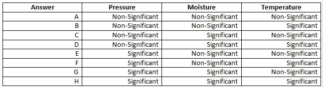

```r
# Read Data
train = read.table('../Data/DATA_4.03_MNT.csv',sep=',',header=TRUE)

# MLR
linregmodel = lm(lifetime~.-broken,data=train)
summary(linregmodel)
```

```
##
## Call:
## lm(formula = lifetime ~ . - broken, data = train)
##
## Residuals:
##     Min      1Q  Median      3Q     Max
## -59.388 -21.788   8.051  21.112  34.891
##
## Coefficients:
##                     Estimate Std. Error t value Pr(>|t|)
## (Intercept)       59.3732039 10.3412622   5.741 1.25e-08 ***
## pressureInd       -0.0031500  0.0416461  -0.076   0.9397
## moistureInd       -0.0173023  0.0830046  -0.208   0.8349
## temperatureInd    -0.0002769  0.0421330  -0.007   0.9948
## teamTeamB          1.5491323  1.9983947   0.775   0.4384
## teamTeamC         -3.4280411  2.0670679  -1.658   0.0976 .
## providerProvider2  0.8835691  2.2944030   0.385   0.7002
## providerProvider3 -9.4858216  2.3490911  -4.038 5.80e-05 ***
## providerProvider4  1.8679357  2.3616268   0.791   0.4292
## ---
## Signif. codes:  0 '***' 0.001 '**' 0.01 '*' 0.05 '.' 0.1 ' ' 1
##
## Residual standard error: 26.13 on 991 degrees of freedom
## Multiple R-squared:  0.0339, Adjusted R-squared:  0.0261
## F-statistic: 4.346 on 8 and 991 DF,  p-value: 3.619e-05
```

```r
library(survival) # Load the survival package

# Dependant variables
dependantvars = Surv(train$lifetime, train$broken)

# survival regression model
survreg = survreg(dependantvars~pressureInd+moistureInd+temperatureInd+team+provider, dist="gaussian",data=train)
summary(survreg)
```

```
##
## Call:
## survreg(formula = dependantvars ~ pressureInd + moistureInd +
##     temperatureInd + team + provider, data = train, dist = "gaussian")
##                       Value Std. Error        z        p
## (Intercept)        8.04e+01    0.29371  273.574 0.00e+00
## pressureInd       -7.14e-04    0.00122   -0.587 5.57e-01
## moistureInd        6.01e-03    0.00240    2.505 1.22e-02
## temperatureInd    -1.04e-02    0.00121   -8.593 8.49e-18
## teamTeamB         -5.67e-02    0.05882   -0.964 3.35e-01
## teamTeamC         -6.22e+00    0.06132 -101.392 0.00e+00
## providerProvider2  1.25e+01    0.06665  187.464 0.00e+00
## providerProvider3 -1.44e+01    0.06275 -229.241 0.00e+00
## providerProvider4  7.92e+00    0.07056  112.233 0.00e+00
## Log(scale)        -7.43e-01    0.03540  -20.998 6.86e-98
##
## Scale= 0.476
##
## Gaussian distribution
## Loglik(model)= -270.1   Loglik(intercept only)= -1557
##  Chisq= 2573.75 on 8 degrees of freedom, p= 0
## Number of Newton-Raphson Iterations: 12
## n= 1000
```

**B, Only Temperature**

4. For the Predictive Maintenance dataset (DATA_4.03_MNT.csv), if you use as explanatory variables only the Pressure, Moisture and Temperature indices (hence removing the teams and providers information), which one of the following is correct?

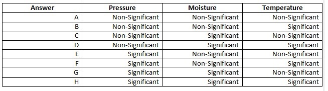

```r
survreg = survreg(dependantvars~pressureInd+moistureInd+temperatureInd, dist="gaussian",data=train) #
summary(survreg)
```

```
##
## Call:
## survreg(formula = dependantvars ~ pressureInd + moistureInd +
##     temperatureInd, data = train, dist = "gaussian")
##                  Value Std. Error      z        p
## (Intercept)    75.8525     5.9187 12.816 1.34e-37
## pressureInd     0.0228     0.0249  0.913 3.61e-01
## moistureInd     0.0394     0.0495  0.796 4.26e-01
## temperatureInd -0.0223     0.0251 -0.889 3.74e-01
## Log(scale)      2.3528     0.0340 69.187 0.00e+00
##
## Scale= 10.5
##
## Gaussian distribution
## Loglik(model)= -1555.9   Loglik(intercept only)= -1557
##  Chisq= 2.19 on 3 degrees of freedom, p= 0.53
## Number of Newton-Raphson Iterations: 6
## n= 1000
```

**A, None is significant**

5. For the Predictive Maintenance dataset (DATA_4.03_MNT.csv), using the same specifications as seen during the videos, what is the ID of the element that has the largest expected remaining lifetime?

```r
# Specifications
survreg = survreg(dependantvars~pressureInd+moistureInd+temperatureInd+team+provider, dist="gaussian",data=train) # Create your survival regression model

# Predictions on Expected breaking time
Ebreak=predict(survreg, newdata=train, type="quantile", p=.5)

# Data Frame
Forecast=data.frame(Ebreak)
# Lifetime
Forecast$lifetime = train$lifetime

# Is piece broken?
Forecast$broken=train$broken
Forecast = Forecast %>% mutate(RemainingLT = Ebreak - lifetime) %>%  mutate(index = 1:nrow(Forecast)) %>% filter(broken ==0)

# Largest Expected remaining Life
df = Forecast %>% arrange(desc(RemainingLT))
kable(head(df))
```

| Ebreak | lifetime | broken | RemainingLT | index |
| --- | --- | --- | --- | --- |
| 92.24826 | 1 | 0 | 91.24826 | 53 |
| 92.55563 | 2 | 0 | 90.55563 | 472 |
| 92.31880 | 2 | 0 | 90.31880 | 877 |
| 92.87914 | 3 | 0 | 89.87914 | 225 |
| 92.69553 | 4 | 0 | 88.69553 | 708 |
| 92.27872 | 5 | 0 | 87.27872 | 852 |

53